# Day 3: Synthesis and Creation: With Answers

Cleo Falvey & Filip Stefanovic

8/2/2020

# Welcome back!

Today we’re going to be synthesizing and implementing Tidyverse! If today’s RMarkdown looks a little bit empty to you, that’s because we’re going to be all making it together!

Also, Cleo will send out a GitHub at the end so everyone has working code by the end of the day. In addition, to see how we prepared for this workshop (mainly because live coding demos stress us out), check out the “bonus_content.Rmd” file included in the Day 3 materials (this will also be on GitHub).

# Putting it all together

Today is going to be a little different than usual. We’re going to all code together! We’ll going to start everyone off with a little bit of readr/dplyr, but then we’re all going to split out into breakout groups and make graphs. It may be helpful to have yesterday’s .html file on hand, so you can remember the dplyr and ggplot2 syntax.

- setosa, width ratio (group 1)
- versicolor, length ratio (group 2)
- virginica, width ratio (group 3)
- versicolor, sepal to petal length ratio (group 4)
- virginica, sepal to petal width ratio (group 5)

Here, the length ratio is taken to be the ratio of the sepal length/width over the petal length/width, while the sepal to petal ratio can be made by taking the sepal length/width and dividing it by the petal length/width. However, do not worry to much about this, we will cover again during the session!

Let’s do it to it! :)

### Load Your Packages

```r
#today, we will keep using the tidyverse package. you can call it up using the library() function.
library(tidyverse)
```

### Reading Data

Read in your data here. The data is a file in the working directory called “iris.csv”. It’s about different types of flowers. It is a very famous dataset in the R world, and is often used for teaching purposes.

```r
# read in your data here and save it to your environment under iris. hint: use read_csv().

iris <- read_csv("iris.csv")
```

### ggplot2

Once you’ve taken a look at the data, let’s consider what kinds of graphs we can make and what stories we can tell. For this next section, you will run the chunk each time you add to the code, this way you can get a sense of how your graph grows over time. To do this, simply press control + shift + enter (windows) or command + shift + return (apple).

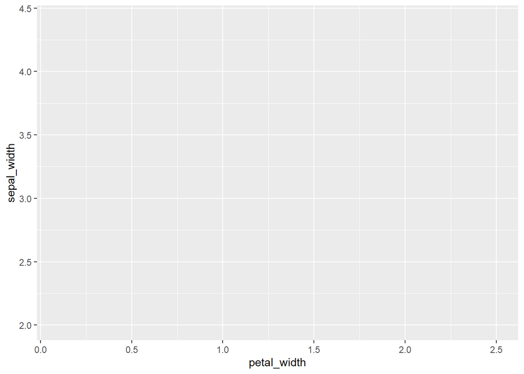

```r
# what plots do we think are interesting? this is an open-ended question; there is no right answer! however, always think about the data story we want to tell. To start, lets see if there is any relationship between petal width and sepal width.

#start by setting up ggplot: set the axes and add some color

ggplot(data=iris, aes(x=petal_width, y=sepal_width, color=species))
```

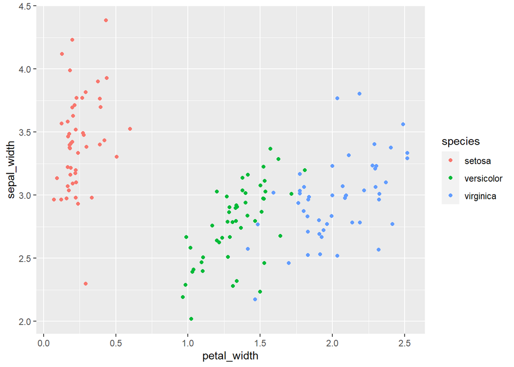

```r
#now create a scatterplot

ggplot(data=iris, aes(x=petal_width, y=sepal_width, color=species)) +
  geom_jitter()
```

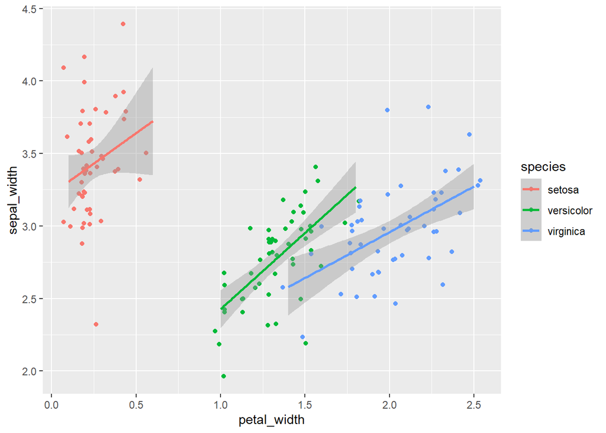

```r
#a nice addition would be a line of best fit, for this we use geom_smooth(method = "lm")

ggplot(data=iris, aes(x=petal_width, y=sepal_width, color=species)) +
  geom_jitter() +
  geom_smooth(method="lm")
```

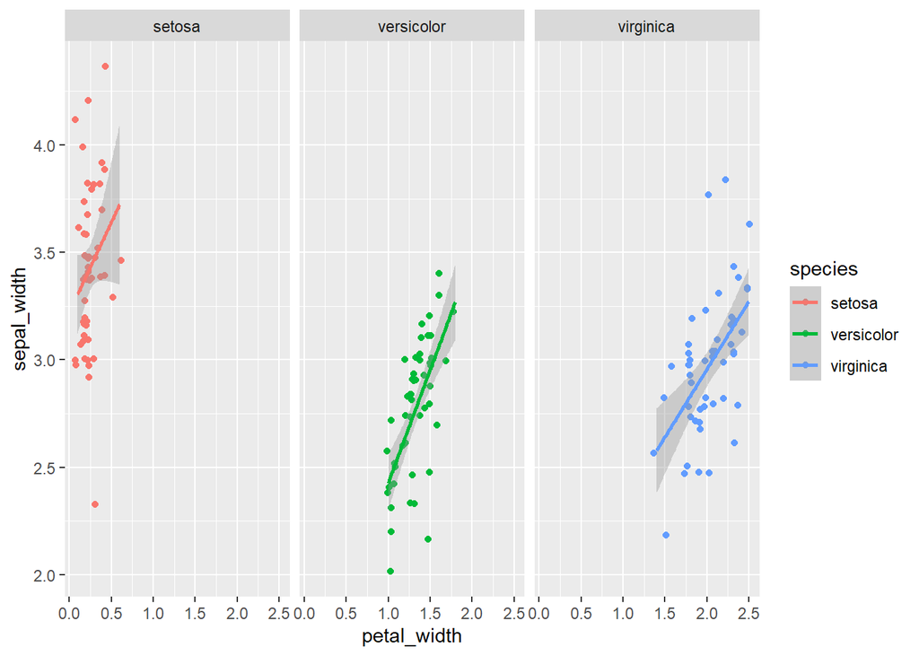

```r
#I wonder what our graph would look like if it were explicitly graphed by species... We achieve this by the addition of a facet_wrap(~species).

ggplot(data=iris, aes(x=petal_width, y=sepal_width, color=species)) +
  geom_jitter() +
  geom_smooth(method="lm") +
  facet_wrap(~species)
```

### dplyr

Now let’s get back to some data manipulation!

```r
# we've done some exploratory plotting. is there any way we need to change the shape or mutate our data files? what could be interesting?

#start by naming a new variable and assign it to a data frame

mutated_iris <- iris %>%
  mutate(
    petal_ratio = petal_length / petal_width,
    sepal_ratio = sepal_length / sepal_width,
    petal_area = petal_length * petal_width,
    sepal_area = sepal_length * sepal_width
  )

#now let's choose one species to work with; first, let's explore setosa

setosa <- mutated_iris %>%
  filter(species=="setosa")

virginica <- mutated_iris %>%
  filter(species=="virginica")

versicolor <- mutated_iris %>%
  filter(species=="versicolor")
```

### ggplot2 (the sequel)

Now that we have narrowed down our dataset and manipulated it to create a new variable, let’s make a ggplot2 graph!

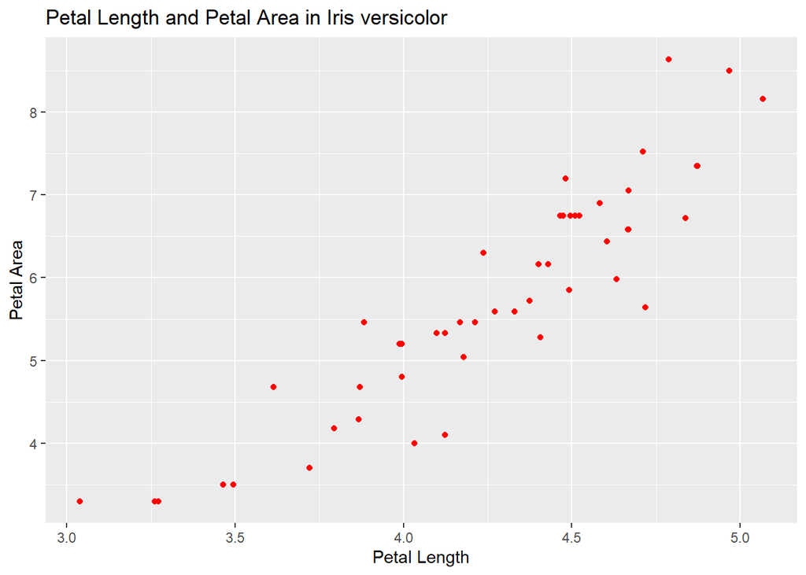

```r
#make a ggplot

ggplot(data=versicolor, aes(x=petal_length, y=petal_area)) +
  geom_jitter(color="red") +
  labs(x="Petal Length", y="Petal Area", title="Petal Length and Petal Area in Iris versicolor")
```

### Modelling

To see how these trends stack up over each species, let’s make some linear models.

```r
# let's create a linear model of the relationship between two variables we think are interesting.

petal_length_area_versicolor <- lm(formula = petal_area ~petal_length, data=versicolor)


#first call the function lm(). then, specify the formula and data. don't forget to assign it to a variable!

#now inspect the variable using the summary function

summary(petal_length_area_versicolor)
```

```
##
## Call:
## lm(formula = petal_area ~ petal_length, data = versicolor)
##
## Residuals:
##      Min       1Q   Median       3Q      Max
## -1.25599 -0.31484 -0.02073  0.35907  1.47683
##
## Coefficients:
##              Estimate Std. Error t value Pr(>|t|)
## (Intercept)   -5.6614     0.7164  -7.902 3.09e-10 ***
## petal_length   2.6718     0.1672  15.982  < 2e-16 ***
## ---
## Signif. codes:  0 '***' 0.001 '**' 0.01 '*' 0.05 '.' 0.1 ' ' 1
##
## Residual standard error: 0.5499 on 48 degrees of freedom
## Multiple R-squared:  0.8418, Adjusted R-squared:  0.8385
## F-statistic: 255.4 on 1 and 48 DF,  p-value: < 2.2e-16
```

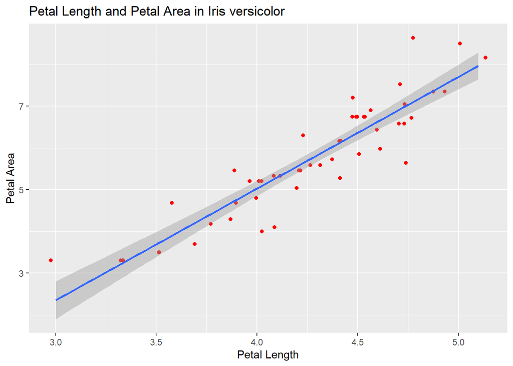

```r
# a graph with lm added

ggplot(data=versicolor, aes(x=petal_length, y=petal_area)) +
  geom_jitter(color="red") +
  labs(x="Petal Length", y="Petal Area", title="Petal Length and Petal Area in Iris versicolor") +
  geom_smooth(method="lm")
```

Now it’s your turn! After each chunk, insert a new one with your own code and analyses. You can do this either by clicking the insert button on top of your script pane or by using alt + control + I (windows) or option + command + I (apple). Take ~30-min to recreate these plots and analyses. Once we are all finished, we will reconvene and each group will share their result and try to interpret them!

# Miscellaneous Takeaways: Day 3

- One of the most common bugs is actually using %>% for ggplot2 and + for dplyr. We ALWAYS use %>% for dplyr and + for ggplot2!
- See the “bonus_content.Rmd” file for more analyses, tips, and tricks that are already ready-to-run (i.e., hit “knit” to run it yourself, or open up the .html file!)

### Enjoy your R journey and have a great rest of your summer! Thanks much for participating! If you ever have an R question feel free to reach Cleo at cleo.falvey001@umb.edu :) She is very responsive to emails and is almost guaranteed to get back to you within 24 hours.

### Filip will also gladly hear from you and will try his best to respond at Filip.Stefanovic001@umb.edu !